### Part II

#### Solution

Tuesday, November 17, 2015

**4.** Of interest are two active volcanoes ($X$ and $Y$) and estimating the number of eruptions in a given year. It is assumed that the number of eruptions for both volcanoes follow independent Poisson distributions. It is also assumed that volcano $Y$ erupts $\gamma$ times more often than volcano $X$. Recall that the pmf for $X$ is then $f_X(x, \lambda) = \frac{e^{-\lambda}\lambda^x}{x!}; \ \ \ x = 0, 1, \dots; \ \ \ \lambda > 0$ and for $Y$ is $f_Y(y, \gamma, \lambda) = \frac{e^{-\gamma \lambda}(\gamma \lambda)^y}{y!}; \ \ \ y = 0, 1, \dots ; \ \ \ \gamma, \lambda > 0$ The data can be found in the file `prob4.dat` where the first column is $X$ and the second column is $Y$.

1. Find the maximum likelihood estimators for $\lambda$ and $\gamma$ [you do not need to check second derivatives].  
   **Solution**  
   $\begin{aligned} L(\lambda, \gamma) &= \prod_{i=1}^m f_X(x_i, \gamma) \cdot \prod_{j=1}^n f_Y(y_j, \gamma, \lambda) \\ \ell(\lambda, \gamma) &= \log \left(\prod_{i=1}^m \frac{e^{-\lambda}\lambda^{x_i}}{x_i!} \cdot \prod_{j=1}^n \frac{e^{-\gamma \lambda}(\gamma \lambda)^{y_j}}{y_j!}\right) \\ &= \sum_{i=1}^m \log \left(\frac{e^{-\lambda}\lambda^x_i}{x_i!}\right) + \sum_{j=1}^n \log \left(\frac{e^{-\gamma \lambda}(\gamma \lambda)^y_j}{y_j!}\right) \\ &= \sum_{i=1}^m \big[\log e^{-\lambda} + \log \lambda^{x_i} - \log x_i!\big] + \sum_{j=1}^n \big[ \log e^{-\gamma \lambda} + \log (\gamma \lambda)^{y_j} - \log y_j! \big] \\ &= \sum_{i=1}^m \big[(-\lambda)\log e + (x_i)\log \lambda - \log x_i!\big] + \sum_{j=1}^n \big[ (-\gamma \lambda)\log e + (y_j) \log (\gamma \lambda) - \log y_j! \big] \\ &= -m \lambda + (\log \lambda)\sum_{i=1}^m x_i - \sum_{i=1}^m \log x_i! - n \gamma \lambda + \big[\log (\gamma \lambda) \big] \sum_{j=1}^n y_j - \sum_{j=1}^n \log y_j! \\ \end{aligned}$ Derivative $\ell(\lambda, \gamma)$ wrt $\lambda$ $\begin{align*} \frac{\partial \ell(\lambda, \gamma)}{\partial \lambda} &= -m + \frac{1}{\lambda} \sum_{i=1}^m x_i - 0 - n \gamma + \frac{1}{\gamma \lambda}\gamma \sum_{j=1}^n y_j - 0 \\ &= -m + \frac{1}{\lambda} \sum_{i=1}^m x_i - n \gamma + \frac{1}{\lambda} \sum_{j=1}^n y_j \tag*{(1)} \end{align*}$ Derivative $\ell(\lambda, \gamma)$ wrt $\gamma$ $\begin{align*} \frac{\partial \ell(\lambda, \gamma)}{\partial \gamma} &= 0 + 0 -0 -n \lambda + \frac{1}{\gamma \lambda}\lambda \sum_{j=1}^n y_j - 0 \\ &= -n \lambda + \frac{1}{\gamma} \sum_{j=1}^n y_j \tag*{(2)} \end{align*}$ Maximize by setting both partial derivatives to zero, solve for $\lambda$ in the latter equation (2) to get $\lambda = \frac{\sum y_j}{n \gamma}$, and substitute into the former equation (1): $\begin{align*} 0 &= -m + \frac{1}{\lambda} \sum_{i=1}^m x_i - n \gamma + \frac{1}{\lambda} \sum_{j=1}^n y_j \\ &= -m + \frac{n \gamma}{\sum_{j=1}^n y_j} \sum_{i=1}^m x_i - n \gamma + \frac{n \gamma}{\sum_{j=1}^n y_j} \sum_{j=1}^n y_j \\ &= -m + \frac{n \gamma}{n \overline{Y}}m \overline{X} - n \gamma + n\gamma \\ &= -m + \frac{m \gamma \overline{X}}{\overline{Y}} \\ \hat{\gamma} &= \frac{\overline{Y}}{\overline{X}} \end{align*}$ Plug in $\hat{\gamma}$ into $\lambda = \frac{\sum y_j}{n \gamma}$ to get $\begin{align*} \lambda &= \frac{\sum_{j=1}^n y_j}{n \hat{\gamma}} \\ &= \frac{\sum_{j=1}^n y_j}{n (\overline{Y}/\overline{X})} \\ &= \frac{\overline{X} n \overline{Y}}{n \overline{Y}} \\ \hat{\lambda} &= \overline{X} \end{align*}$
2. Use a resampling method to estimate the standard error of the estimators from part (a) using the data. Include all code.  
   **Solution** Read in data

```r
raw.text <- ' # B/c double quotes are in data, use single quotes.
"x" "y"       # There are 3 columns but only 2 column names, so ignore header
"1" 4 19
"2" 4 19
"3" 3 15
"4" 4 11
"5" 3 20
"6" 3 20
"7" 3 19
"8" 2 17
"9" 0 14
"10" 3 16
"11" 2 18
"12" 1 15
"13" 3 14
"14" 5 6
"15" 5 14
"16" 2 14
"17" 4 13
"18" 2 19
"19" 3 16
"20" 2 10
"21" 6 15
"22" 3 10
"23" 5 8
"24" 2 22
"25" 4 13
'

volcano.df <- read.table(header=FALSE, skip=2, text=raw.text)
volcano.df[,1] <- NULL # delete first column - irrelevant
names(volcano.df) <- c("x", "y") # add column names

# Bootstrap
lambda.hat <- c()
gamma.hat <- c()
sample.size <- nrow(volcano.df) # n=25

# Note: In this bootstrap, you cannot sample x and y independently.
#       You are sampling observations, so sample by randomly selecting row numbers.
set.seed(12345)
for (bupkis in 1:5000){
  row.number <- c(1:25)
  rows.to.extract <- sample(x=row.number, size=sample.size, replace=TRUE)
  sample.x <- volcano.df$x[rows.to.extract]
  sample.y <- volcano.df$y[rows.to.extract]
  lambda.hat[bupkis] <- mean(sample.x)
  gamma.hat[bupkis] <- mean(sample.y)/mean(sample.x)
}
( est.std.err.lambda.hat <- sd(lambda.hat) ) #[0.2655573]
```

```
## [1] 0.2674451
```

```r
( est.std.err.gamma.hat <- sd(gamma.hat) ) #[0.5617283]
```

```
## [1] 0.5511775
```

3. Use large sample theory of the MLE to construct 95% confidence intervals for $\lambda$ and $\gamma$.  
   **Solution**  
   Determining a 95% confidence interval using large sample theory is given by (Section 8.5.3, pg 281) $\hat{\theta} \pm z_{(\alpha/2)} \frac{1}{\sqrt{nI(\hat{\theta})}}$ where $\frac{1}{nI(\hat{\theta})}$ is the asymptotic variance.  
   For $\lambda$:

```r
mean(lambda.hat) + c(-1.96*est.std.err.lambda.hat, 1.96*est.std.err.lambda.hat)
```

```
## [1] 2.599208 3.647592
```

For $\gamma$:

```r
mean(gamma.hat) + c(-1.96*est.std.err.gamma.hat, 1.96*est.std.err.gamma.hat)
```

```
## [1] 3.785098 5.945714
```

4. Use the bootstrap method to approximate 95% confidence intervals for $\lambda$ and $\gamma$ without using the normal distribution. Comment.  
   Include all code.  
   **Solution**  
   For $\lambda$:

```r
quantile(x=lambda.hat, probs=c(0.025, 0.975))
```

```
##  2.5% 97.5%
##  2.60  3.64
```

For $\gamma$:

```r
quantile(x=gamma.hat, probs=c(0.025, 0.975))
```

```
##     2.5%    97.5%
## 3.886310 6.029423
```

“The CIs look very similar which is not surprising since histograms of the two sets of bootstrap estimates appears normal.”

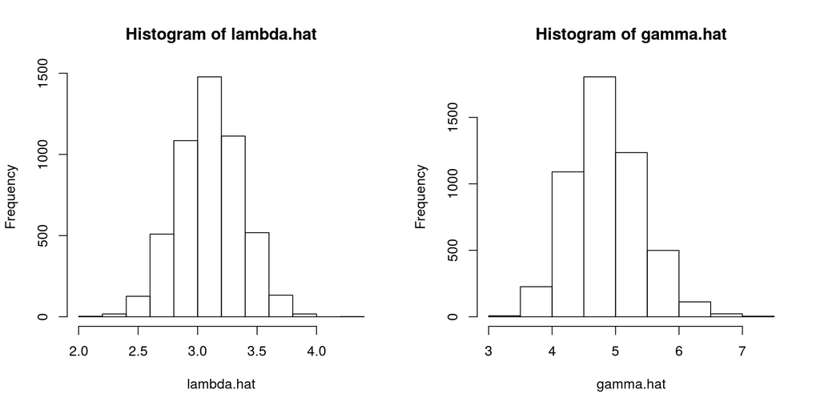

```r
hist(lambda.hat)
hist(gamma.hat)
```